# Recidivism Analysis

Course: Data Mining with Dr. Diane Igoche

Group 12: Moses Hetfield, Sormeh Yazdi, and Kayla Reiman

May 2020

# **Team Notes**

****Delete this notes section eventually****

#### **Outstanding conceptual questions**

- How do we decide which classification model(s) to try? Just try as many as we have time for and then compare misclassificaiton rates?
- How does the video about the importance of splitting the data before starting relate to K-fold CV, which we learned about next as the better alternative?
- How do we deal with the 59 variables, given that it’s bad data mining practice to drop anything?
- What is a cox validation study?
- How did ProPublica decide on a logistic regression using low/high as the outcome? `glm(formula = score_factor ~ gender_factor + age_factor + race_factor + priors_count + crime_factor + two_year_recid, family = "binomial", data = df)`
- Why are the datasets of violent crimes and regular crimes separate? Why are there different sample sizes? Why can’t we just merge them?

#### **To do list**

- **High level of effort**
  - Validation: Figure out how we should be splitting our data into training/validation from the beginning so we don’t make [this mistake](https://canvas.cmu.edu/courses/14656/files/4676325?module_item_id=4438423). Then document it at the start of section 2.
  - Improve KR’s descriptions of possible models in 2a.1: Model Selection and validation. You can use the book’s section called “4.5 A Comparison of Classification Methods” as a resource. Then decide which models to use.
- **Medium level of effort**
- **Low level of effort**
  - Switch to relative path referencing while importing CSVs

#### **Tasks for later**

- **Medium level of effort**
  - Model Selection and validation (2a.1): run our first model!
- **High level of effort**
  - Figure out the best version of a given model (ex. logistic regression) using test/training error and figuring out if we can incorporate sensitivity/specifity in choosing the version of the model.
  - Compare models (ex. logistic regression vs. random forrest)
  - Make pretty pictures about how our models performed (lift charts, ROC curves, sensitivity vs. specificity)

#### **List of resources**

[Our github repo](https://github.com/kaylareiman1/RecidivismPrediction)  
[ProPublica main article](https://www.propublica.org/article/machine-bias-risk-assessments-in-criminal-sentencing)  
[ProPublica methodology](https://www.propublica.org/article/how-we-analyzed-the-compas-recidivism-algorithm)  
[ProPublica github](https://github.com/propublica/compas-analysis)  
[Raw version of COMPAS survey](https://www.documentcloud.org/documents/2702103-Sample-Risk-Assessment-COMPAS-CORE.html)  
[Columbia article on Risk as proxy for race (2010)](https://papers.ssrn.com/sol3/papers.cfm?abstract_id=1677654) [Article on Risk, Race, and Recidivism](https://papers.ssrn.com/sol3/papers.cfm?abstract_id=2687339)  
[Original publication by COMPAS creator](http://www.northpointeinc.com/files/publications/Criminal-Justice-Behavior-COMPAS.pdf)  
[Assignment instructions on Canvas](https://canvas.cmu.edu/courses/14656/modules/items/4432299)  
[Project description on Canvas](https://canvas.cmu.edu/courses/14656/modules/items/4443203)

****End of team notes****

# **Introduction**

#### **Background**

In 2016, ProPublica published a [story](https://www.propublica.org/article/machine-bias-risk-assessments-in-criminal-sentencing) on how a commonly-used pre-trial risk assessment tool called the COMPAS is racially biased. The journalists showed that in spite of a 2009 validation study showing similar accuracy rates for black and white men (67 percent versus 69 percent), the inacccuracies were in opposite directions for the two groups. This racial bias of the tool is reflected in their their published table replicated below:

| Type of error | White | African American |
| --- | --- | --- |
| Labeled Higher Risk, But Didn’t Re-Offend | 23.5% | 44.9% |
| Labeled Lower Risk, Yet Did Re-Offend | 47.7% | 28.0% |

#### **Prompt**

- Using the available data, construct a Risk Assessment Instrument (RAI) for predicting two-year recidivism.
  - Evaluate the predictive performance of your model.
  - What are the most important predictors of recidivism?
- Create an RAI for predicting violent recidivism.
  - Evaluate the predictive performance of your model.
  - What are the most important predictors of violent recidivism?
  - How do they compare to the important predictors of general recidivism?
- Assess whether the RAIs from (A) and (B) are equally predictive across race/ethnicity groups? How about across age and gender_factor groups?
- Compare your RAIs to the COMPAS RAI.
  - Do your RAIs perform better or worse than COMPAS?
  - Do your RAIs produce similar classifications to COMPAS?
  - Can you identify any systematic differences between your classifications and those of COMPAS?

#### **Goal**

Our goal is to investigate whether it is possible to create a Risk Assessment Instrument (RAI) that is more accurate and less racist than the COMPAS.

#### **Data**

This analysis is run using ProPublica’s data. In order to have clean data, it is necessary to remove certain observations. Fortunately, ProPublica staff published their [Jupyter notebook](https://github.com/propublica/compas-analysis/blob/master/Compas%20Analysis.ipynb) with data cleaning steps in R, so our data is cleaned in the same way (ex. dropping people whose charge date was not w/in 30 days ). However, although we drop the same observations (rows) as they do, we have adapted their code so that it does not drop any attributes (columns) because this would be bad practice for data mining.

# **Section 1: Exploratory Data Analysis**

#### **1a: Overview of datasets**

[KR note: must check whether 1 person per row or different row driver]

This project uses 2 datasets from [ProPublica’s github repository](https://github.com/propublica/compas-analysis), which are described in the table below:

| Dataset name | original obs | obs after cleaning | # varibles |
| --- | --- | --- | --- |
| recid.all | 7214 | 6172 | 59 |
| recid.vio | 4743 | 4020 | 59 |

Out of the 59 variables in each dataset, we first looked at the variables in the logistic that ProPublica ran to see how well recidivism could predict whether somebody was flagged as low-risk. Their code is pasted below:  
`glm(formula = score_factor ~ gender_factor + age_factor + race_factor + priors_count + crime_factor + two_year_recid, family = "binomial", data = df)`

An overview of variables that ProPublica used is below: [KR note: this dictionary could be better.] - two_year_recid: this is the variable that ProPublica used to indicate recidivism in each dataset.  
- score_factor: the binary variable indicating low risk vs. medium/high risk. - Other covariates: -gender_factor: male vs. female -age_factor: a 3-level categorical variable for age -race_factor: from the original race variable. As will be shown below, most categories have very few observations.  
-crime_factor: felonies vs. misdimeanors -priors_count: prior infractions?

A list of all of the variables in the dataset is shown below:

```r
#It'll be ideal if we can delete this section eventually (or make it prettier). However, I'm leaving this here so you can get to know the data better without running everything from scratch.

colnames.all <- colnames(recid.all)
colnames.vio <- colnames(recid.vio)

#Print full list of columns
colnames.all
```

```
##  [1] "id"                      "name"
##  [3] "first"                   "last"
##  [5] "compas_screening_date"   "sex"
##  [7] "dob"                     "age"
##  [9] "age_cat"                 "race"
## [11] "juv_fel_count"           "decile_score"
## [13] "juv_misd_count"          "juv_other_count"
## [15] "priors_count"            "days_b_screening_arrest"
## [17] "c_jail_in"               "c_jail_out"
## [19] "c_case_number"           "c_offense_date"
## [21] "c_arrest_date"           "c_days_from_compas"
## [23] "c_charge_degree"         "c_charge_desc"
## [25] "is_recid"                "r_case_number"
## [27] "r_charge_degree"         "r_days_from_arrest"
## [29] "r_offense_date"          "r_charge_desc"
## [31] "r_jail_in"               "r_jail_out"
## [33] "violent_recid"           "is_violent_recid"
## [35] "vr_case_number"          "vr_charge_degree"
## [37] "vr_offense_date"         "vr_charge_desc"
## [39] "type_of_assessment"      "decile_score_1"
## [41] "score_text"              "screening_date"
## [43] "v_type_of_assessment"    "v_decile_score"
## [45] "v_score_text"            "v_screening_date"
## [47] "in_custody"              "out_custody"
## [49] "priors_count_1"          "start"
## [51] "end"                     "event"
## [53] "two_year_recid"          "length_of_stay"
## [55] "crime_factor"            "age_factor"
## [57] "race_factor"             "gender_factor"
## [59] "score_factor"
```

```r
#Print columns that differ
colnames.vio[(colnames.vio != colnames.all)]
```

```
## [1] "two_year_recid_1"
```

```r
colnames.all[(colnames.vio != colnames.all)]
```

```
## [1] "length_of_stay"
```

Given the multiple posibilities for recidivism outcome variables, the tables below show the checks that were run to determine that two_year_recid is the correct outcome variable to use in both datasets. [KR note: mabe delete this later. But for now, it would be great if somebody can confirm that you agree with this conclusion or decide whether we should create a new variable for violent recidivism or something].

How variables relate in recid.all dataset

| two_year_recid | is_recid | is_violent_recid | violent_recid | count |
| --- | --- | --- | --- | --- |
| 0 | 0 | 0 | NA | 3182 |
| 0 | 1 | 0 | NA | 141 |
| 0 | 1 | 1 | NA | 40 |
| 1 | 1 | 0 | NA | 2157 |
| 1 | 1 | 1 | NA | 652 |

How variables relate in recid.vio dataset

| two_year_recid | two_year_recid_1 | is_recid | is_violent_recid | violent_recid | count |
| --- | --- | --- | --- | --- | --- |
| 0 | 0 | 0 | 0 | NA | 3187 |
| 0 | 0 | 1 | 0 | NA | 141 |
| 0 | 0 | 1 | 1 | NA | 40 |
| 1 | 1 | 1 | 1 | NA | 652 |

#### **1b: Demographic Characteristics**

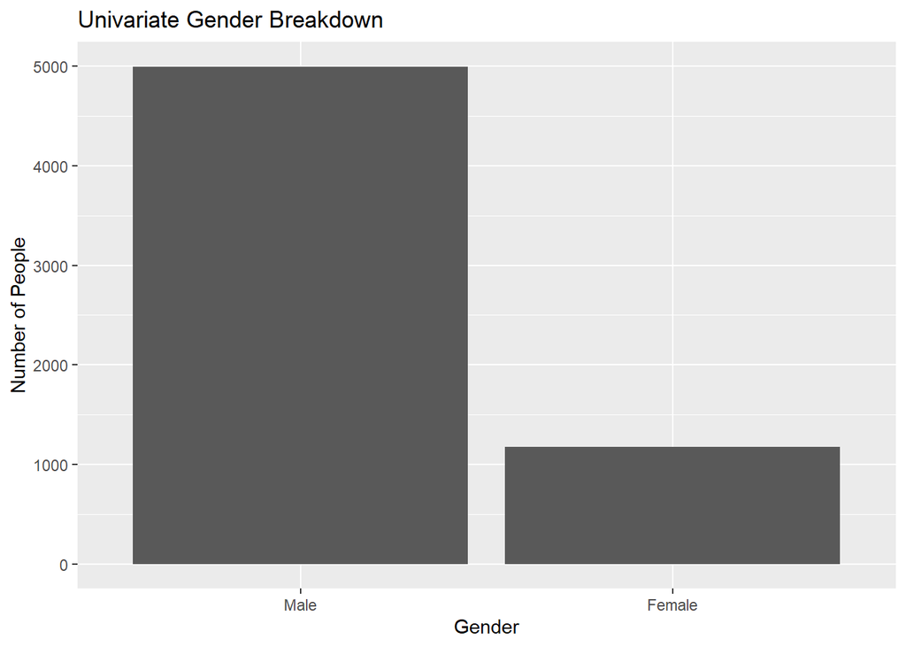

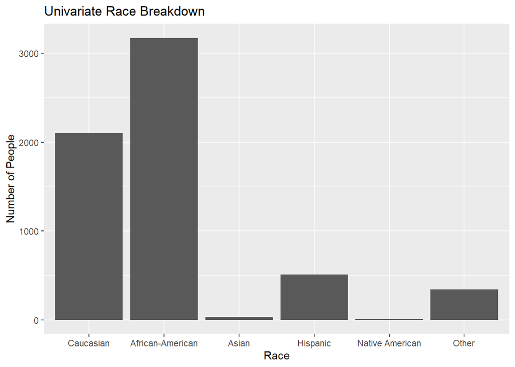

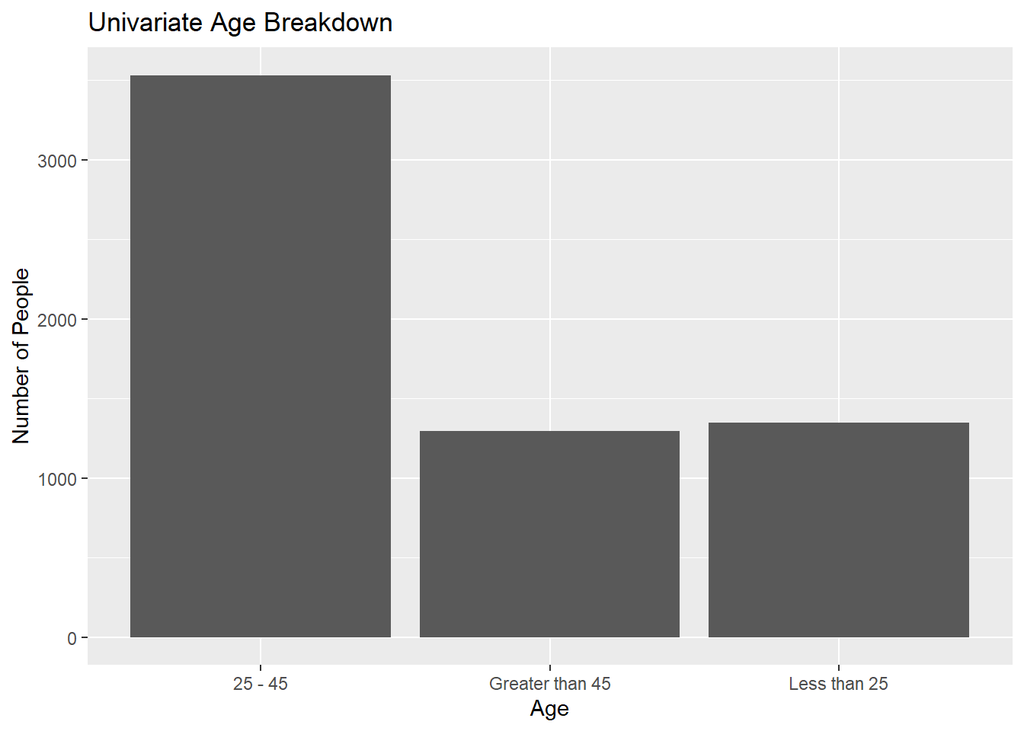

#### **1c: Recidivism Rates**

The table below shows how common two-year recidivism of both types was in our dataset.

| Dataset | Two-year Rate |
| --- | --- |
| All recidivism (recid.all) | 46% |
| Violent recidivism (recid.vio) | 16% |

#### **1d: COMPAS Predictions**

The graphs below show participants’ 10-point scores, where a score of 10 indicates the highest recidivism potential. Judges were often shown categories of low, medium, and high risk. The ProPublica analysis combined the categories of medium and high in order to create a binary variable called score_factor with two categories.

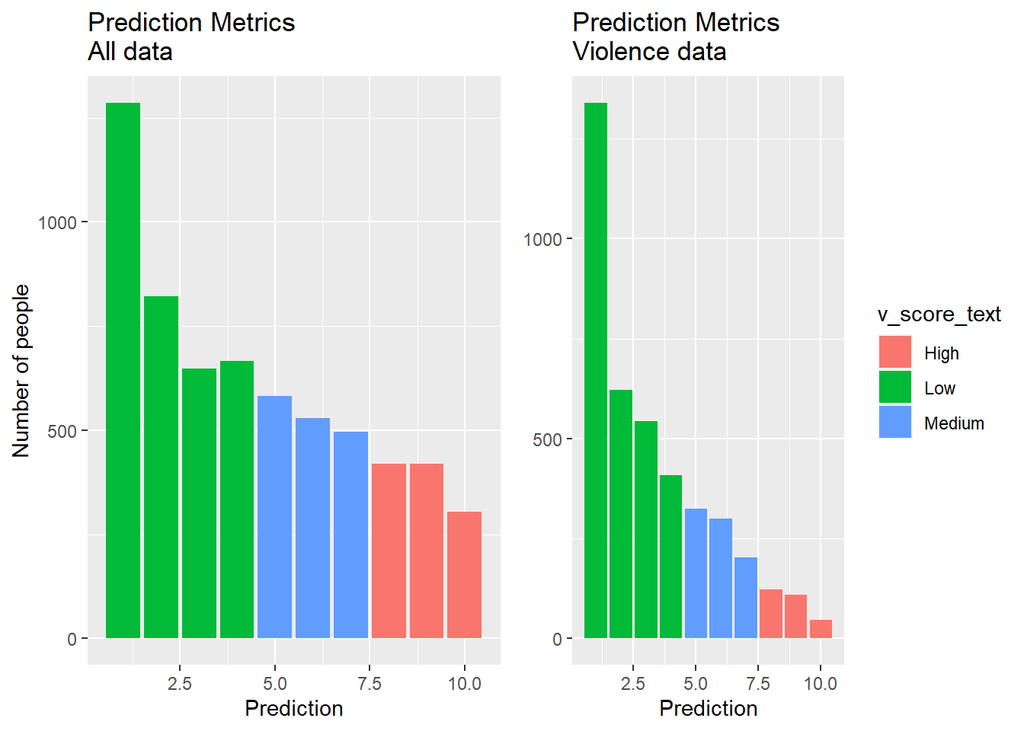

#### **1e: Accuracy of Predictions by Demographic Group**

[KR note to team: I actually expected these wouldn’t look alike at all. But by the time I finished this, I’d spent so much time adapting code from our good ol’ NLSY project that now I want to keep them.] Initial data exploration showed that the trends in recidivism were similar to predictions. However, a few limitations should be noted:  
- The higher rate of recidivism among African-American respondents cannot be separated from bias in policing [cite Michelle Alexander].  
- This includes no interactions between terms demographic characteristics (ex. race and gender)  
- As ProPublica pointed out, these charts do not differentiate between false positives and false negatives.

Additionally, we already know from the univariate race graphs that the recidivism rates for groups other than White, Hispanic, and African-American people will be distorted by a small sample size. [KR note: perhaps we should drop these obs or create a new race var?]

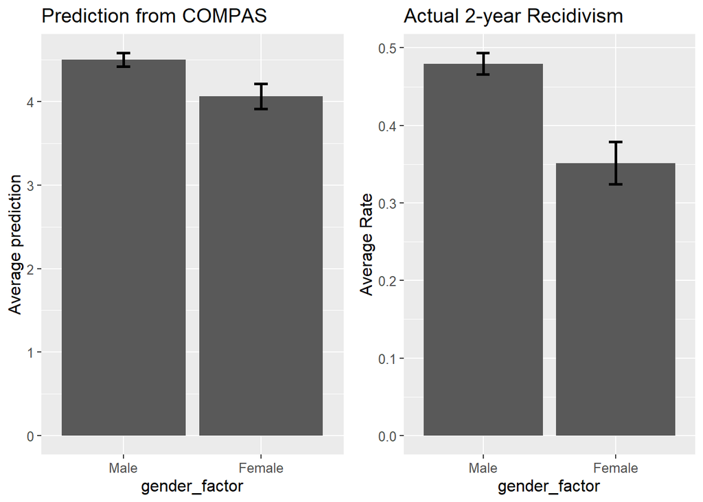

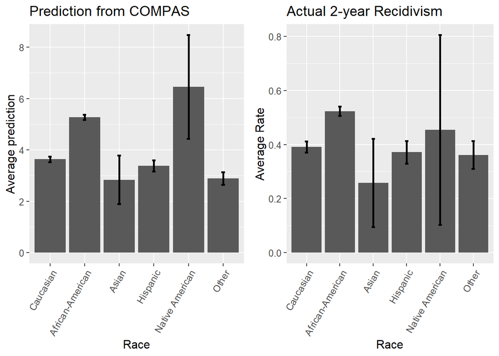

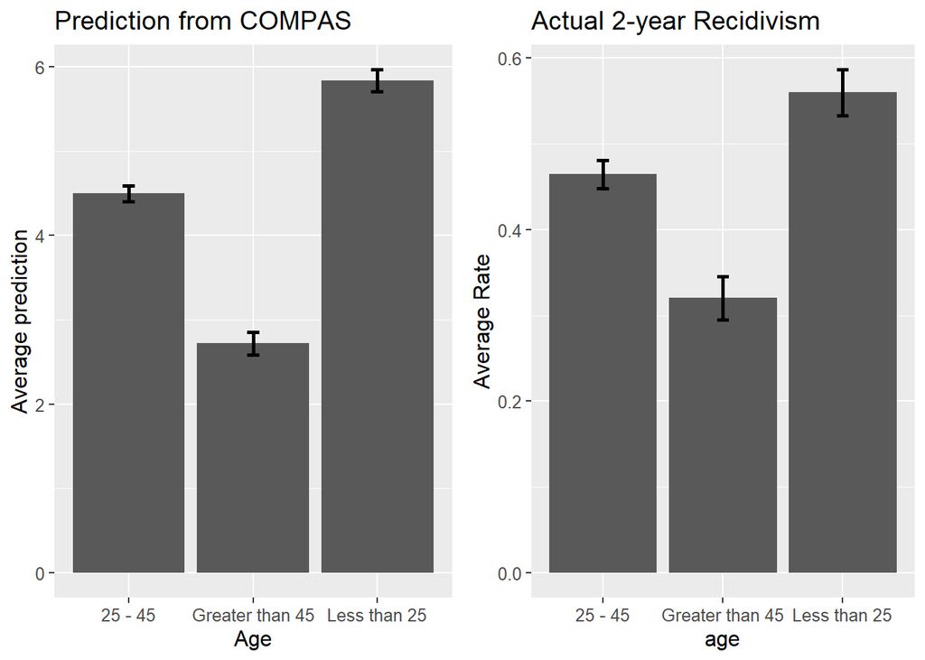

# **Section 2: Methodology**

Prior to starting the data mining process, we randomly split the data into training and validation sets.

#### **2a: Data Mining Methods and Performance**

**2a.1: Model Selection and validation**

**Possible models**  
[KR note to team: we may cut some of these if we a) don’t have time or b) think they’re the wrong models]  
Given our task of predicting binary outcomes, we considered the following classification methods:  
- Logistic regression:  
- Naive Bayes (NB): This works when there is no interaction between predictors.  
- Linear Discriminant Analysis (LDA): This works when the interaction between predictors is the same across classes.  
- Quadratic Discriminant Analysis (QDA): This works when there are class-based interactions among the predictors  
- Random Forrest (RF): - Classification Tree: Although not as trustworthy as random forrest, the potential for public transparency makes this worth trying.  
- K-Nearest Neighbors (KNN):

To decide between models, we looked at three measures of error: -Accuracy: This is the percent of predictions that were correct. It is a limited measure of the tool’s usefulness because it counts false positives and false negatives in the same way, when their human impact is much different.  
-Specifity: This shows the true negative rate. A higher number shows that we are not mistakenly classifying people as high-risk. general, we believe this is the most important measure because it keeps innocent people from receiving harsh punishments.  
-Sensitivity: This shows the true positive rate. A higher number shows that we successfully predicted people would commit crimes. For violent crime, a high sensitivity rate is important.

[output not shown]

[output not shown]

**2c: Demographic analysis of the best version of each model:**  
After choosing the best version of each model, we assessed the potential for prejudice. Our goal was to replicate Pro-Publica’s chart for each of these metrics included in the introduction. [If possible, maybe create some charts comparing models on accuracy vs. prejudice tradeoffs]

**2c1: Race**

**2c2: Gender**

**2c3: Age**

#### **2b: Final model(s)**

# **Section 3: Key Findings and Takeaways**

#### **3a: Comparing our tool to the COMPAS tool**

**3a.1: Does our RAIs perform better or worse than COMPAS?**  
**3a.2: Do our RAIs produce similar classifications to COMPAS?**  
**3a.3: Are there systematic differences between our classifications and those of COMPAS?**

#### **3b: Reflections on risk assessment tools**

- We know that arrest data is biased based on where police patrol, so even a model that’s interally sound is still based on biased data.[maybe cite Patrick Ball]
- Pittsburgh has a pre-trial risk assessment tool
- Models can be racist without using race as an input…[maybe add more about our research]
- Black box vs. accessibility

Perhaps cite some articles here, like the two that ProPublica cited, or something more recent [Columbia article on Risk as proxy for race (2010)](https://papers.ssrn.com/sol3/papers.cfm?abstract_id=1677654) [Article on Risk, Race, and Recidivism](https://papers.ssrn.com/sol3/papers.cfm?abstract_id=2687339)

# **References**

[ProPublica main article](https://www.propublica.org/article/machine-bias-risk-assessments-in-criminal-sentencing)  
[ProPublica methodology](https://www.propublica.org/article/how-we-analyzed-the-compas-recidivism-algorithm)  
[ProPublica github](https://github.com/propublica/compas-analysis)  
[Raw version of COMPAS survey](https://www.documentcloud.org/documents/2702103-Sample-Risk-Assessment-COMPAS-CORE.html)